# Hankowsky_HW7

2022-10-19

Hankowsky Homework Solutions

# Basic Problems

## 10.31

```r
#read in the data
parental_care <- Sleuth3::ex1031


#looking at the dataframe
head(parental_care)
```

```
##          CommonName        Genus       Species Group BodyMass ClutchVolume
## 1           Mallard         Anas platyrhynchos   Mat    1.140       542000
## 2     Greylag Goose        Anser         anser   Mat    3.310       797000
## 3         Mute Swan       Cygnus          olor   Mat   10.700      1750000
## 4      Common Eider    Somateria    mollissima   Mat    2.070       475000
## 5 Southern Screamer       Chauna      torquata   BiP    4.400       513000
## 6      Alpine Swift Tachymarptis         melba   BiP    0.103        12400
```

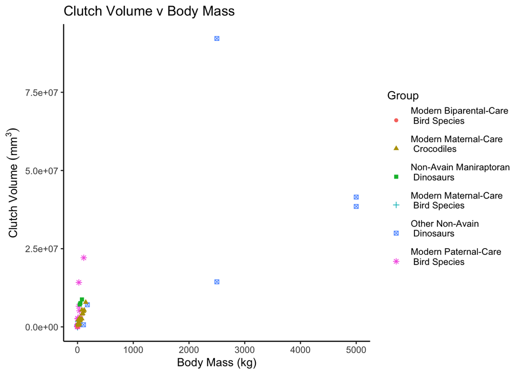

```r
#plot the clutch volume by mass
parental_care %>%
  ggplot() +
  geom_point(aes( x = BodyMass, y =  ClutchVolume, shape = Group, color = Group)) +
  scale_color_discrete(breaks=c("BiP", "Croc", "Mani", "Mat", "Othr", "Pat"),
                      labels=c("Modern Biparental-Care \n Bird Species \n",
                                "Modern Maternal-Care \n Crocodiles \n",
                                "Non-Avain Maniraptoran \n Dinosaurs \n",
                                "Modern Maternal-Care \n Bird Species \n",
                                "Other Non-Avain \n Dinosaurs \n",
                                "Modern Paternal-Care \n Bird Species \n")) +
  scale_shape_discrete(breaks=c("BiP", "Croc", "Mani", "Mat", "Othr", "Pat"),
                      labels=c("Modern Biparental-Care \n Bird Species \n",
                                "Modern Maternal-Care \n Crocodiles \n",
                                "Non-Avain Maniraptoran \n Dinosaurs \n",
                                "Modern Maternal-Care \n Bird Species \n",
                                "Other Non-Avain \n Dinosaurs \n",
                                "Modern Paternal-Care \n Bird Species \n")) +
  labs(title = "Clutch Volume v Body Mass",
       x = "Body Mass (kg)", y = bquote("Clutch Volume " (mm^3))) +
  theme_classic()
```

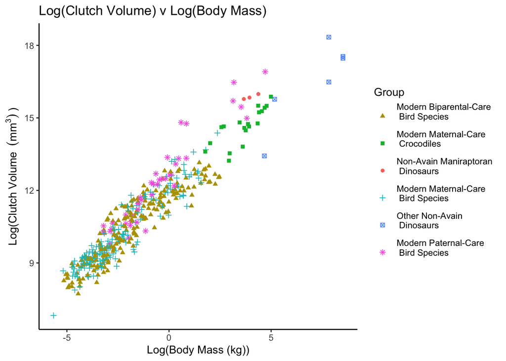

```r
#transforming the data as described in the question
parental_care <- parental_care %>%
  mutate(log_clutch = log(ClutchVolume),
         log_mass = log(BodyMass),
         Group = relevel(Group, ref = "Mani"))


#plot the clutch volume by mass
parental_care %>%
  ggplot() +
  geom_point(aes(x = log_mass, y =  log_clutch, shape = Group, color = Group)) +
  scale_color_discrete(breaks=c("BiP", "Croc", "Mani", "Mat", "Othr", "Pat"),
                      labels=c("Modern Biparental-Care \n Bird Species \n",
                                "Modern Maternal-Care \n Crocodiles \n",
                                "Non-Avain Maniraptoran \n Dinosaurs \n",
                                "Modern Maternal-Care \n Bird Species \n",
                                "Other Non-Avain \n Dinosaurs \n",
                                "Modern Paternal-Care \n Bird Species \n")) +
  scale_shape_discrete(breaks=c("BiP", "Croc", "Mani", "Mat", "Othr", "Pat"),
                      labels=c("Modern Biparental-Care \n Bird Species \n",
                                "Modern Maternal-Care \n Crocodiles \n",
                                "Non-Avain Maniraptoran \n Dinosaurs \n",
                                "Modern Maternal-Care \n Bird Species \n",
                                "Other Non-Avain \n Dinosaurs \n",
                                "Modern Paternal-Care \n Bird Species \n")) +
  labs(title = "Log(Clutch Volume) v Log(Body Mass)",
       x = "Log(Body Mass (kg))", y = bquote("Log(Clutch Volume "~(mm^3)~")")) +
  theme_classic()
```

```r
#run and compare the regression models
parental_care_lm1 <- lm(log_clutch ~ log_mass + Group + log_mass:Group, data = parental_care)
parental_care_lm2 <- lm(log_clutch ~ log_mass + Group, data = parental_care)
parental_care_lm3 <- lm(log_clutch ~ log_mass, data = parental_care)

anova(parental_care_lm2, parental_care_lm1) #testing for interaction effects
```

```
## Analysis of Variance Table
##
## Model 1: log_clutch ~ log_mass + Group
## Model 2: log_clutch ~ log_mass + Group + log_mass:Group
##   Res.Df    RSS Df Sum of Sq      F    Pr(>F)
## 1    436 129.37
## 2    431 122.00  5    7.3691 5.2067 0.0001185 ***
## ---
## Signif. codes:  0 '***' 0.001 '**' 0.01 '*' 0.05 '.' 0.1 ' ' 1
```

```r
anova(parental_care_lm3, parental_care_lm2) #testing for Group effects
```

```
## Analysis of Variance Table
##
## Model 1: log_clutch ~ log_mass
## Model 2: log_clutch ~ log_mass + Group
##   Res.Df    RSS Df Sum of Sq      F    Pr(>F)
## 1    441 156.08
## 2    436 129.37  5    26.709 18.003 3.039e-16 ***
## ---
## Signif. codes:  0 '***' 0.001 '**' 0.01 '*' 0.05 '.' 0.1 ' ' 1
```

```r
#run the optimal regression
parental_care_lm <- lm(log_clutch ~ log_mass + Group + log_mass:Group, data = parental_care)
summary(parental_care_lm)
```

```
##
## Call:
## lm(formula = log_clutch ~ log_mass + Group + log_mass:Group,
##     data = parental_care)
##
## Residuals:
##      Min       1Q   Median       3Q      Max
## -1.40125 -0.33078 -0.01398  0.31449  1.53393
##
## Coefficients:
##                    Estimate Std. Error t value Pr(>|t|)
## (Intercept)         14.6945     4.2169   3.485 0.000543 ***
## log_mass             0.2944     1.0536   0.279 0.780045
## GroupBiP            -2.9212     4.2172  -0.693 0.488884
## GroupCroc           -2.3380     4.2466  -0.551 0.582212
## GroupMat            -2.6946     4.2174  -0.639 0.523208
## GroupOthr           -4.4811     4.3357  -1.034 0.301927
## GroupPat            -1.9423     4.2178  -0.460 0.645390
## log_mass:GroupBiP    0.3820     1.0538   0.362 0.717181
## log_mass:GroupCroc   0.3327     1.0620   0.313 0.754231
## log_mass:GroupMat    0.4691     1.0539   0.445 0.656453
## log_mass:GroupOthr   0.5932     1.0627   0.558 0.576983
## log_mass:GroupPat    0.6010     1.0545   0.570 0.568982
## ---
## Signif. codes:  0 '***' 0.001 '**' 0.01 '*' 0.05 '.' 0.1 ' ' 1
##
## Residual standard error: 0.532 on 431 degrees of freedom
## Multiple R-squared:  0.9243, Adjusted R-squared:  0.9224
## F-statistic: 478.6 on 11 and 431 DF,  p-value: < 2.2e-16
```

```r
#back-transform the estimates
exp(parental_care_lm$coefficients)
```

```
##        (Intercept)           log_mass           GroupBiP          GroupCroc
##       2.408423e+06       1.342338e+00       5.387042e-02       9.651572e-02
##           GroupMat          GroupOthr           GroupPat  log_mass:GroupBiP
##       6.756681e-02       1.132069e-02       1.433753e-01       1.465158e+00
## log_mass:GroupCroc  log_mass:GroupMat log_mass:GroupOthr  log_mass:GroupPat
##       1.394706e+00       1.598548e+00       1.809824e+00       1.824023e+00
```

```r
exp(confint(parental_care_lm))
```

```
##                           2.5 %       97.5 %
## (Intercept)        6.056261e+02 9.577695e+09
## log_mass           1.692427e-01 1.064667e+01
## GroupBiP           1.353769e-05 2.143662e+02
## GroupCroc          2.289439e-05 4.068806e+02
## GroupMat           1.697238e-05 2.689826e+02
## GroupOthr          2.253986e-06 5.685838e+01
## GroupPat           3.598968e-05 5.711774e+02
## log_mass:GroupBiP  1.846597e-01 1.162511e+01
## log_mass:GroupCroc 1.729702e-01 1.124590e+01
## log_mass:GroupMat  2.014457e-01 1.268508e+01
## log_mass:GroupOthr 2.241333e-01 1.461391e+01
## log_mass:GroupPat  2.295745e-01 1.449230e+01
```

```r
100*(exp(parental_care_lm$coef) - 1)
```

```
##        (Intercept)           log_mass           GroupBiP          GroupCroc
##       2.408422e+08       3.423380e+01      -9.461296e+01      -9.034843e+01
##           GroupMat          GroupOthr           GroupPat  log_mass:GroupBiP
##      -9.324332e+01      -9.886793e+01      -8.566247e+01       4.651583e+01
## log_mass:GroupCroc  log_mass:GroupMat log_mass:GroupOthr  log_mass:GroupPat
##       3.947060e+01       5.985480e+01       8.098240e+01       8.240235e+01
```

```r
100*(exp(confint(parental_care_lm)) - 1)
```

```
##                          2.5 %       97.5 %
## (Intercept)        60462.61057 9.577695e+11
## log_mass             -83.07573 9.646669e+02
## GroupBiP             -99.99865 2.133662e+04
## GroupCroc            -99.99771 4.058806e+04
## GroupMat             -99.99830 2.679826e+04
## GroupOthr            -99.99977 5.585838e+03
## GroupPat             -99.99640 5.701774e+04
## log_mass:GroupBiP    -81.53403 1.062511e+03
## log_mass:GroupCroc   -82.70298 1.024590e+03
## log_mass:GroupMat    -79.85543 1.168508e+03
## log_mass:GroupOthr   -77.58667 1.361391e+03
## log_mass:GroupPat    -77.04255 1.349230e+03
```

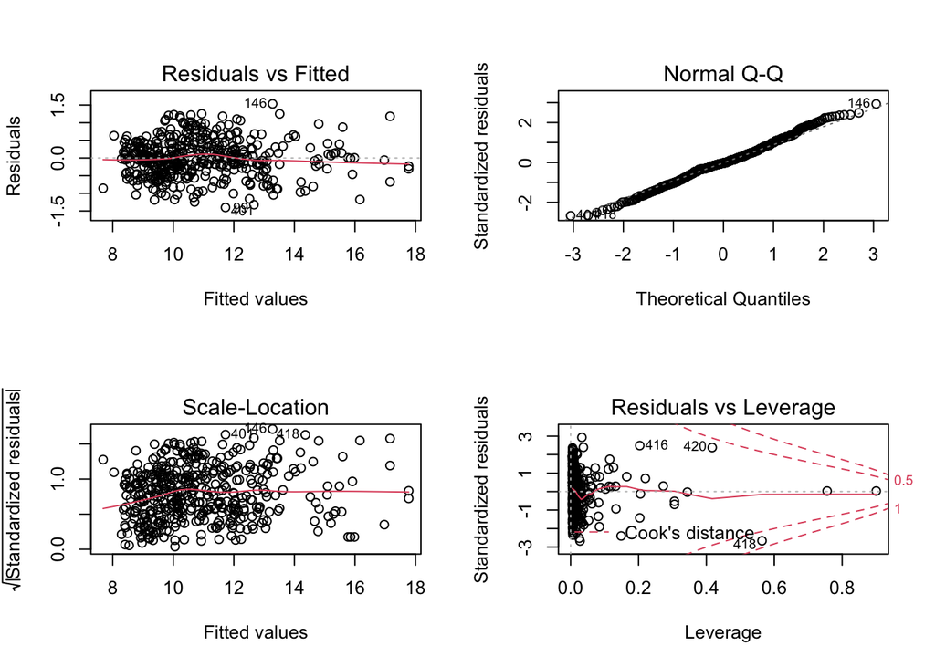

```r
#plot the diagnostics
par(mfrow=c(2,2))
plot(parental_care_lm)
```

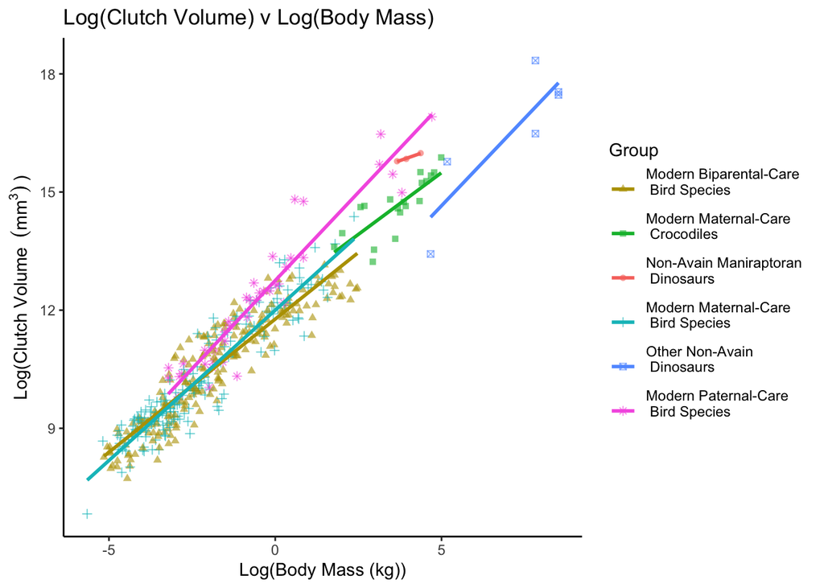

```r
#plot the presentation graphic
par(mfrow=c(1,1))
parental_care %>%
  ggplot(aes(x = log_mass, y =  log_clutch, shape = Group, color = Group)) +
  geom_point(alpha = 0.6) +
  geom_smooth(method = "lm", se = F) +
  scale_color_discrete(breaks=c("BiP", "Croc", "Mani", "Mat", "Othr", "Pat"),
                      labels=c("Modern Biparental-Care \n Bird Species \n",
                                "Modern Maternal-Care \n Crocodiles \n",
                                "Non-Avain Maniraptoran \n Dinosaurs \n",
                                "Modern Maternal-Care \n Bird Species \n",
                                "Other Non-Avain \n Dinosaurs \n",
                                "Modern Paternal-Care \n Bird Species \n")) +
  scale_shape_discrete(breaks=c("BiP", "Croc", "Mani", "Mat", "Othr", "Pat"),
                      labels=c("Modern Biparental-Care \n Bird Species \n",
                                "Modern Maternal-Care \n Crocodiles \n",
                                "Non-Avain Maniraptoran \n Dinosaurs \n",
                                "Modern Maternal-Care \n Bird Species \n",
                                "Other Non-Avain \n Dinosaurs \n",
                                "Modern Paternal-Care \n Bird Species \n")) +
  labs(title = "Log(Clutch Volume) v Log(Body Mass)",
       x = "Log(Body Mass (kg))", y = bquote("Log(Clutch Volume "~(mm^3)~")")) +
  theme_classic()
```

A scatterplot of the raw clutch volume as a function of body mass data showed the need for a transformation. A log-transformation was preformed and the scatterplot showed no problems, so the analysis was conducted with the log-transformed data. There is strong evidence that the relationship between clutch volume and body mass differed between the Mani group and the other groups (Extra Sum of Squares F-Test, p-value < 0.001).

## 11.25

```r
#read in the data
deposit_feeders <- Sleuth3::ex1125

#looking at the dataframe
head(deposit_feeders)
```

```
##                 Species Weight Ingestion Organic Bivalve
## 1     Hydrobia neglecta   0.20      0.57    18.0      no
## 2     Hydrobia ventrosa   0.20      0.86    17.0      no
## 3       Tubifex tubifex   0.27      0.43    29.7      no
## 4       Hyalella azteca   0.32      0.43    50.0      no
## 5 Potamopyrgus jenkinsi   0.46      2.70    14.4      no
## 6        Hydrobia ulvae   0.90      0.67    13.0      no
```

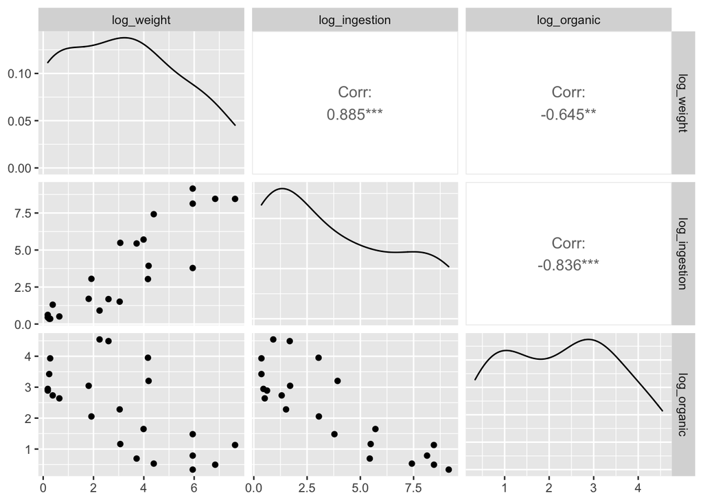

```r
#transforming the data
deposit_feeders <- deposit_feeders %>%
  mutate(log_weight = log(Weight +1),
         log_ingestion = log(Ingestion +1),
         log_organic = log(Organic +1))

#looking at scatterplots of the variables
ggpairs(deposit_feeders, columns = 6:8)
```

```r
#run the mutiple regression
deposit_feeders_lm1 <- lm(log_ingestion ~ log_weight + log_organic + Bivalve, data = deposit_feeders)
summary(deposit_feeders_lm1)
```

```
##
## Call:
## lm(formula = log_ingestion ~ log_weight + log_organic + Bivalve,
##     data = deposit_feeders)
##
## Residuals:
##      Min       1Q   Median       3Q      Max
## -1.25761 -0.34761 -0.09159  0.36689  1.60852
##
## Coefficients:
##             Estimate Std. Error t value Pr(>|t|)
## (Intercept)  3.68381    0.56208   6.554 3.70e-06 ***
## log_weight   0.81958    0.08412   9.743 1.33e-08 ***
## log_organic -0.99739    0.14589  -6.837 2.13e-06 ***
## Bivalveyes  -2.03484    0.42737  -4.761 0.000156 ***
## ---
## Signif. codes:  0 '***' 0.001 '**' 0.01 '*' 0.05 '.' 0.1 ' ' 1
##
## Residual standard error: 0.6847 on 18 degrees of freedom
## Multiple R-squared:  0.9575, Adjusted R-squared:  0.9504
## F-statistic:   135 on 3 and 18 DF,  p-value: 1.576e-12
```

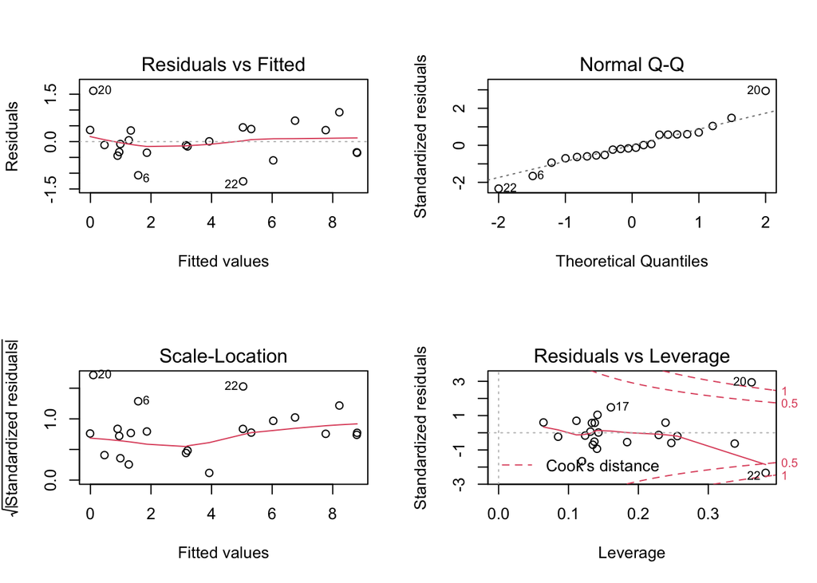

```r
#plot the diagnostics
par(mfrow=c(2,2))
plot(deposit_feeders_lm1)
```

```r
plot(deposit_feeders_lm1, which = 4)


#plot the dfbetas plot
#plotting it dr gallaghers way
deposit_feeders_lm1_dfbs <- dfbetas(deposit_feeders_lm1)
head(deposit_feeders_lm1_dfbs)
```

```
##   (Intercept)  log_weight  log_organic   Bivalveyes
## 1 -0.17886358  0.19737340  0.067834032  0.042946425
## 2 -0.13759301  0.14969426  0.056345264  0.031325236
## 3 -0.02494194  0.03344574 -0.002623793  0.011156596
## 4  0.02663673 -0.07257318  0.077250448 -0.043499046
## 5  0.01775128 -0.01844585 -0.008211044 -0.003925328
## 6 -0.46946805  0.46985752  0.223977471  0.111259274
```

```r
plot(deposit_feeders_lm1_dfbs[ , c("log_weight", "log_organic")],
     main="dfbetas plot")
identify(deposit_feeders_lm1_dfbs[ ,"log_weight"],deposit_feeders_lm1_dfbs[ ,"log_organic"])
```

```
## integer(0)
```

```r
#plotting it using the olsrr::ols_plot_dfbetas
ols_plot_dfbetas(deposit_feeders_lm1)
```

[figure not shown]

```r
#re-run the regression without observation 22
#creating an ID number for each row
deposit_feeders <- deposit_feeders %>%
  mutate(ID = 1:nrow(deposit_feeders)) %>%
  relocate(ID)

#re-run regression
deposit_feeders_lm2 <- update(deposit_feeders_lm1, ~ ., subset = (ID != 20 & ID != 22))

#plot the diagnostics of the updated regression
par(mfrow=c(2,2))
```

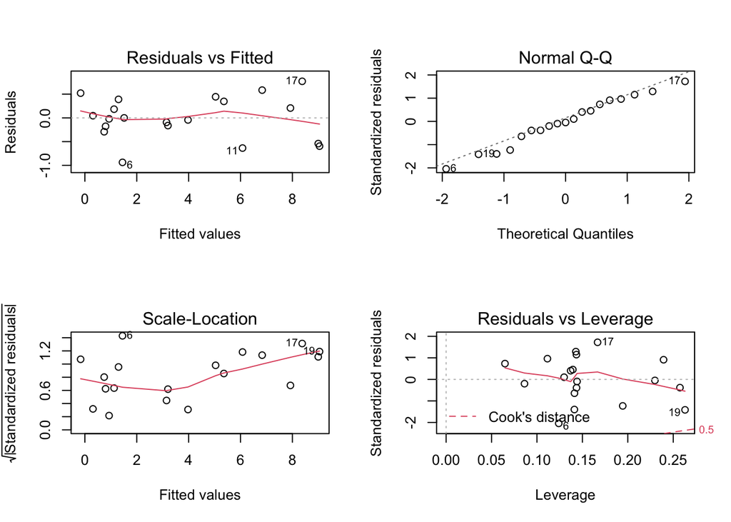

```r
plot(deposit_feeders_lm2)
```

```r
plot(deposit_feeders_lm2, which = 4)

#plot the dfbetas plot
ols_plot_dfbetas(deposit_feeders_lm2)
```

```r
#looking at teh bivalve effect
deposit_feeders_lm3 <- lm(log_ingestion ~ log_weight + log_organic, data = deposit_feeders,
                          subset = (ID != 20 & ID != 22))

anova(deposit_feeders_lm3, deposit_feeders_lm2) #testing for bivalve effects
```

```
## Analysis of Variance Table
##
## Model 1: log_ingestion ~ log_weight + log_organic
## Model 2: log_ingestion ~ log_weight + log_organic + Bivalve
##   Res.Df    RSS Df Sum of Sq      F    Pr(>F)
## 1     17 9.2409
## 2     16 3.8430  1    5.3979 22.474 0.0002216 ***
## ---
## Signif. codes:  0 '***' 0.001 '**' 0.01 '*' 0.05 '.' 0.1 ' ' 1
```

```r
#looking at the final model
summary(deposit_feeders_lm3)
```

```
##
## Call:
## lm(formula = log_ingestion ~ log_weight + log_organic, data = deposit_feeders,
##     subset = (ID != 20 & ID != 22))
##
## Residuals:
##      Min       1Q   Median       3Q      Max
## -2.26447 -0.23319  0.08283  0.47631  0.88990
##
## Coefficients:
##             Estimate Std. Error t value Pr(>|t|)
## (Intercept)  3.40691    0.60814   5.602 3.17e-05 ***
## log_weight   0.87305    0.09298   9.390 3.87e-08 ***
## log_organic -1.00044    0.15730  -6.360 7.11e-06 ***
## ---
## Signif. codes:  0 '***' 0.001 '**' 0.01 '*' 0.05 '.' 0.1 ' ' 1
##
## Residual standard error: 0.7373 on 17 degrees of freedom
## Multiple R-squared:  0.9524, Adjusted R-squared:  0.9468
## F-statistic: 170.1 on 2 and 17 DF,  p-value: 5.739e-12
```

[figure not shown]

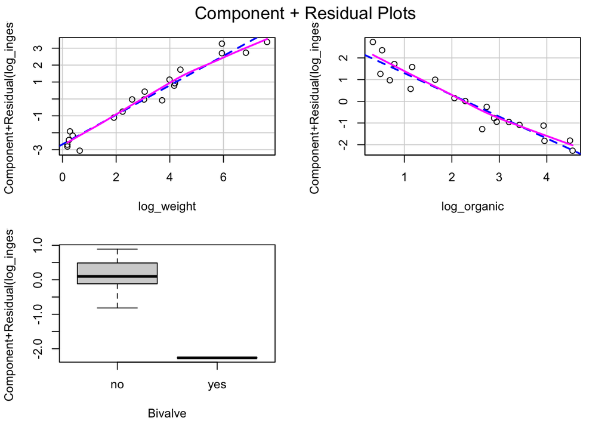

```r
#compoenent residual plots
crPlots(deposit_feeders_lm2)
```

```r
#back transforming the data
exp(deposit_feeders_lm2$coefficients)
```

```
## (Intercept)  log_weight log_organic  Bivalveyes
## 34.40823461  2.38966251  0.36670249  0.09220353
```

```r
exp(confint(deposit_feeders_lm2))
```

```
##                   2.5 %     97.5 %
## (Intercept) 14.57515502 81.2290921
## log_weight   2.09619770  2.7242120
## log_organic  0.29379733  0.4576989
## Bivalveyes   0.03175467  0.2677241
```

```r
100*(exp(deposit_feeders_lm2$coefficients) - 1)
```

```
## (Intercept)  log_weight log_organic  Bivalveyes
##  3340.82346   138.96625   -63.32975   -90.77965
```

```r
100*(exp(confint(deposit_feeders_lm2)) - 1)
```

```
##                  2.5 %     97.5 %
## (Intercept) 1357.51550 8022.90921
## log_weight   109.61977  172.42120
## log_organic  -70.62027  -54.23011
## Bivalveyes   -96.82453  -73.22759
```

There is strong evidence that the relationship between ingestion rate and the percentage of organic matter in food and animal weight differed between bivalves and non-bivalves (Extra Sum of Squares F-Test, p-value < 0.001). However, two of the bivalve observations were considerable outliers and were removed from the analysis. Thus, the bivalve term is only being fitted to one observation and I did not think it was appropriate to fit a model with a bivalve term if there was only one bivalve observation in the dataset.

These data provide overwhelming evidence that the ingestion rate is associated with the percentage of organic matter in food, after accounting for animal weight (p-value < 0.0001, multiple regression).

# Supplemental Problems

## 10.32

```r
#read in the data
height <- Sleuth3::ex0726


#looking at the dataframe
head(height)
```

```
##   Gender Family Height Father Mother
## 1   male      1   73.2   78.5   67.0
## 2 female      1   69.2   78.5   67.0
## 3 female      1   69.0   78.5   67.0
## 4 female      1   69.0   78.5   67.0
## 5   male      2   73.5   75.5   66.5
## 6   male      2   72.5   75.5   66.5
```

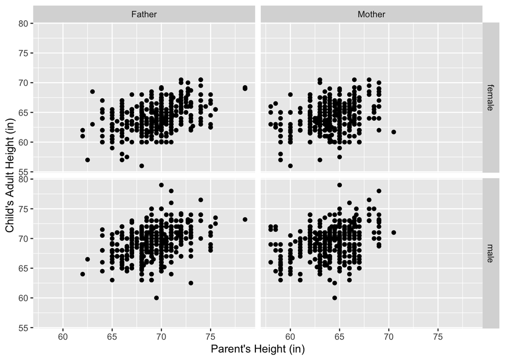

```r
#transposing the data
height_long <- height %>%
  pivot_longer(cols = c("Father", "Mother"),
               names_to = "parent",
               values_to = "parent_height")


#plot
height_long %>%
  ggplot() +
  geom_point(aes(x = parent_height, y =  Height)) +
  facet_grid(Gender ~ parent) +
  labs(x = "Parent's Height (in)", y = "Child's Adult Height (in)")
```

```r
#regression
height_lm <- lm(Height ~ Mother + Father + Gender, data = height)
summary(height_lm)
```

```
##
## Call:
## lm(formula = Height ~ Mother + Father + Gender, data = height)
##
## Residuals:
##     Min      1Q  Median      3Q     Max
## -9.5280 -1.4604  0.0996  1.4783  9.1161
##
## Coefficients:
##             Estimate Std. Error t value Pr(>|t|)
## (Intercept) 16.43221    2.72802   6.023 2.46e-09 ***
## Mother       0.31840    0.03102  10.263  < 2e-16 ***
## Father       0.39339    0.02868  13.718  < 2e-16 ***
## Gendermale   5.21902    0.14188  36.784  < 2e-16 ***
## ---
## Signif. codes:  0 '***' 0.001 '**' 0.01 '*' 0.05 '.' 0.1 ' ' 1
##
## Residual standard error: 2.165 on 929 degrees of freedom
## Multiple R-squared:  0.6358, Adjusted R-squared:  0.6346
## F-statistic: 540.5 on 3 and 929 DF,  p-value: < 2.2e-16
```

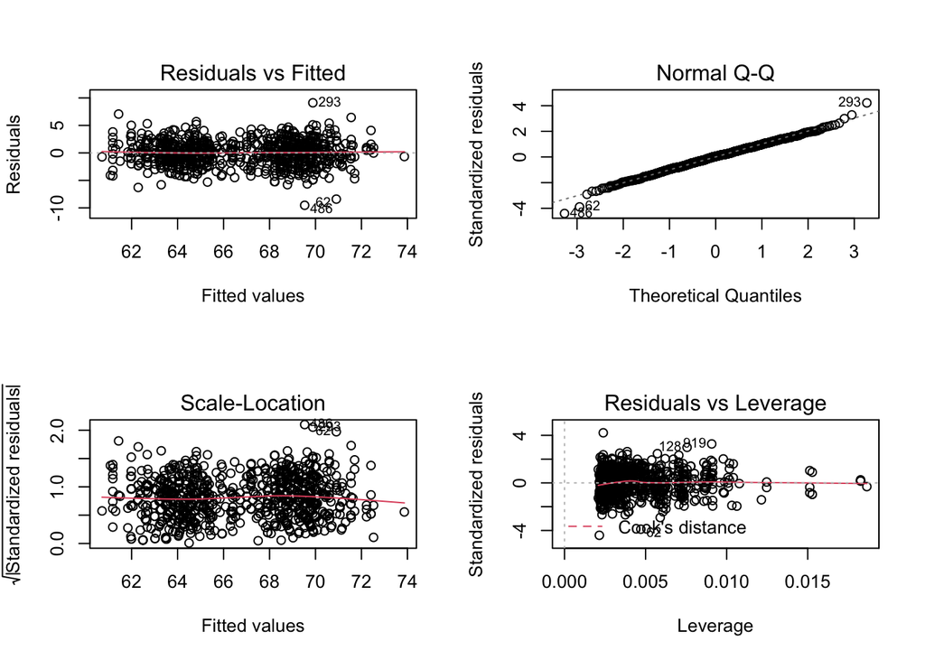

```r
#plot the diagnostics
par(mfrow=c(2,2))
plot(height_lm)
```

The equation for predicting a child’s adult height from their mother’s height, their father’s height, and their gender is y = 16.43 + 0.32(Mother’s Height) + 0.39(Father’s Height) + 5.22(Male Gender).

## 12.20

```r
#read in the data
galapagos <- Sleuth3::ex1220

#looking at the dataframe
head(galapagos)
```

```
##         Island Total Native  Area Elev DistNear DistSc AreaNear
## 1       Baltra    58     23 25.09  332      0.6    0.6     1.84
## 2    Bartolome    31     21  1.24  109      0.6   26.3   572.33
## 3     Caldwell     3      3  0.21  114      2.8   58.7     0.78
## 4     Champion    25      9  0.10   46      1.9   47.4     0.18
## 5      Coamano     2      1  1.05  130      1.9    1.9   903.82
## 6 Daphne Major    18     11  0.34  119      8.0    8.0     1.84
```

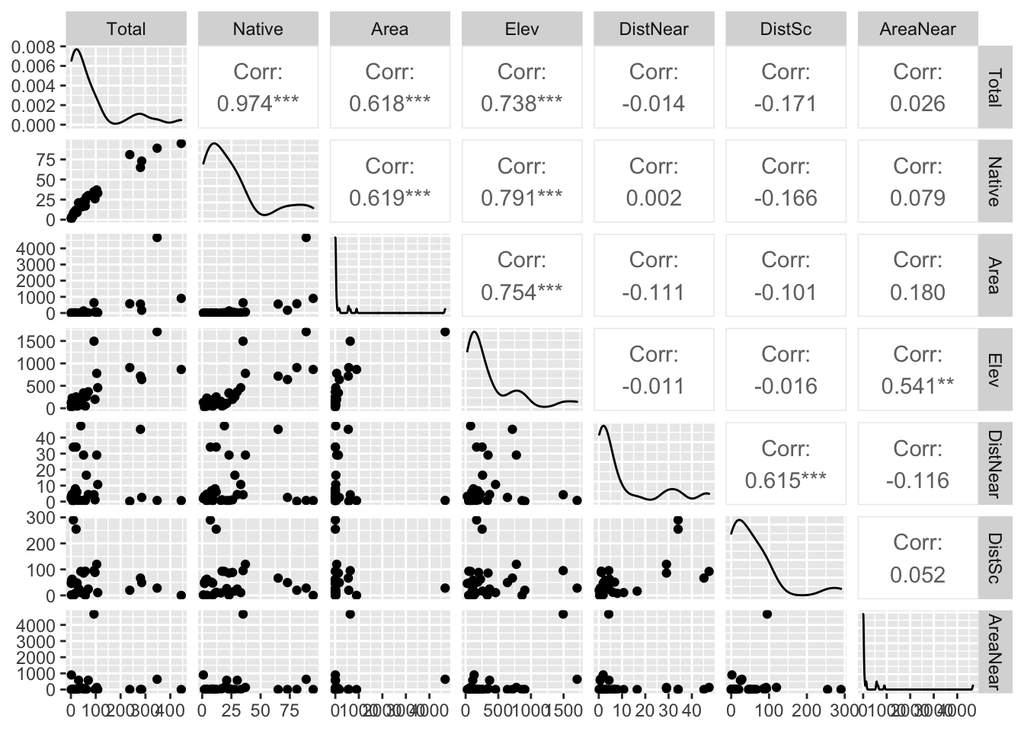

```r
#looking at scatterplots of the variables
ggpairs(galapagos, columns = 2:8)
```

```r
#fit a model with all the variables
galapagos_lm1 <- lm(Total ~ Area, data = galapagos)
summary(galapagos_lm1)
```

```
##
## Call:
## lm(formula = Total ~ Area, data = galapagos)
##
## Residuals:
##     Min      1Q  Median      3Q     Max
## -99.484 -53.429 -29.042   3.425 306.141
##
## Coefficients:
##             Estimate Std. Error t value Pr(>|t|)
## (Intercept) 63.78062   17.52500   3.639 0.001095 **
## Area         0.08196    0.01971   4.158 0.000275 ***
## ---
## Signif. codes:  0 '***' 0.001 '**' 0.01 '*' 0.05 '.' 0.1 ' ' 1
##
## Residual standard error: 91.73 on 28 degrees of freedom
## Multiple R-squared:  0.3817, Adjusted R-squared:  0.3596
## F-statistic: 17.29 on 1 and 28 DF,  p-value: 0.000275
```

```r
galapagos_lm2 <- lm(Total ~ Area + Elev, data = galapagos)
summary(galapagos_lm2)
```

```
##
## Call:
## lm(formula = Total ~ Area + Elev, data = galapagos)
##
## Residuals:
##      Min       1Q   Median       3Q      Max
## -192.476  -34.124  -16.739    7.293  261.585
##
## Coefficients:
##             Estimate Std. Error t value Pr(>|t|)
## (Intercept) 17.05963   20.98899   0.813  0.42345
## Area         0.01886    0.02598   0.726  0.47410
## Elev         0.17165    0.05330   3.221  0.00332 **
## ---
## Signif. codes:  0 '***' 0.001 '**' 0.01 '*' 0.05 '.' 0.1 ' ' 1
##
## Residual standard error: 79.4 on 27 degrees of freedom
## Multiple R-squared:  0.5533, Adjusted R-squared:  0.5202
## F-statistic: 16.72 on 2 and 27 DF,  p-value: 1.884e-05
```

```r
galapagos_lm3 <- lm(Total ~ Area + DistSc, data = galapagos)
summary(galapagos_lm3)
```

```
##
## Call:
## lm(formula = Total ~ Area + DistSc, data = galapagos)
##
## Residuals:
##     Min      1Q  Median      3Q     Max
## -98.352 -57.512 -18.833   0.213 296.528
##
## Coefficients:
##             Estimate Std. Error t value Pr(>|t|)
## (Intercept) 74.72345   23.17252   3.225 0.003290 **
## Area         0.08049    0.01998   4.028 0.000411 ***
## DistSc      -0.18530    0.25380  -0.730 0.471605
## ---
## Signif. codes:  0 '***' 0.001 '**' 0.01 '*' 0.05 '.' 0.1 ' ' 1
##
## Residual standard error: 92.51 on 27 degrees of freedom
## Multiple R-squared:  0.3937, Adjusted R-squared:  0.3488
## F-statistic: 8.765 on 2 and 27 DF,  p-value: 0.001166
```

```r
galapagos_lm4 <- lm(Total ~ Area + AreaNear, data = galapagos)
summary(galapagos_lm4)
```

```
##
## Call:
## lm(formula = Total ~ Area + AreaNear, data = galapagos)
##
## Residuals:
##     Min      1Q  Median      3Q     Max
## -104.39  -53.96  -27.46   21.87  301.75
##
## Coefficients:
##             Estimate Std. Error t value Pr(>|t|)
## (Intercept) 66.27521   18.26096   3.629 0.001170 **
## Area         0.08406    0.02029   4.144 0.000302 ***
## AreaNear    -0.01166    0.02028  -0.575 0.569993
## ---
## Signif. codes:  0 '***' 0.001 '**' 0.01 '*' 0.05 '.' 0.1 ' ' 1
##
## Residual standard error: 92.85 on 27 degrees of freedom
## Multiple R-squared:  0.3892, Adjusted R-squared:  0.3439
## F-statistic: 8.602 on 2 and 27 DF,  p-value: 0.001288
```

```r
galapagos_lm2 <- lm(Total ~ Area + Elev + DistSc + AreaNear, data = galapagos)
summary(galapagos_lm2)
```

```
##
## Call:
## lm(formula = Total ~ Area + Elev + DistSc + AreaNear, data = galapagos)
##
## Residuals:
##      Min       1Q   Median       3Q      Max
## -114.223  -34.601   -8.395   22.489  180.655
##
## Coefficients:
##             Estimate Std. Error t value Pr(>|t|)
## (Intercept)  5.86380   18.61351   0.315    0.755
## Area        -0.02551    0.02137  -1.193    0.244
## Elev         0.32474    0.05103   6.363 1.16e-06 ***
## DistSc      -0.23851    0.16283  -1.465    0.155
## AreaNear    -0.07659    0.01657  -4.621 9.95e-05 ***
## ---
## Signif. codes:  0 '***' 0.001 '**' 0.01 '*' 0.05 '.' 0.1 ' ' 1
##
## Residual standard error: 59.09 on 25 degrees of freedom
## Multiple R-squared:  0.7709, Adjusted R-squared:  0.7343
## F-statistic: 21.03 on 4 and 25 DF,  p-value: 1.063e-07
```